# Online Shopping

Project 2

Technology has revolutionized many areas, such as education, and has turned our daily lives upside down especially with the emergence of Internet. It has completely changed the way we work, communicate with others or purchase items. E-commerce makes it simpler than ever to buy things without leaving our homes. This ease has made online shopping very popular among people of all ages and backgrounds. Millions of transactions happen online every day.

In this perspective,, we will analyse the data set “2_online_shopping” and find a model explaining customer behavior on an e-commerce website.

To achieve this goal, we will proceed in five parts. In the first two parts, we will describe, explore and treat the data set to understand some clients’ behaviors and gain initial insights. Then in the third part, we will identify a suitable model that we will carefully interpret. We will then analyze the model’s performance and evaluate its effectiveness. Finally, we will conclude by discussing about the model and its implications. To further enhance our analysis, we will introduce a sixth part, where we will explore the possibility of a better model.

# 1 Description of the Data Set

We identify the variable of interest as the `purchase` variable, a binary one, it takes the value “TRUE” if a purchase has been made and “FALSE” otherwise. The proportion of “TRUE” in this data can be calculated as 0.16. This type indicates that a logistic model might be appropriate for the problem at hand. However, it is important to examine all the features present in the set before constructing the model.

The customer behavior on the e-commerce website can intuitively be explained by many factors: the type of product sales, the date (for instance if we approach Valentine’s Day), the design of the website, the customer profile, …

That is why this data set, which aims to be as representative as possible, regroups a lot of features, 17 in total with a large diversity. As numerical variables we have :

And as categorical variables :

- Month (`month`) - which month the session took place (one level for each month)
- Weekend (`weekend`) - binary indicator of whether the session took place during a weekend
- Operating Systems (`operating_sys`) - operating systems of the users (with four levels : “1”, “2” and “3” the most popular one, and “4” which represents the others)
- Browser (`browser`) - web browsers of the users (with three levels : “1” and “2” the most popular one, and “3” which represents the others)
- Region (`region`) - geographic region in which the user is located (one number for each region)
- Traffic Type (`traffic_type`) - where from the user arrived at the site (there is 6 different arrived possible and the last one represent the “others” category)
- Visitor Type (`visitor_type`) - with 3 levels (new visitor, returning visitor and the other category)

The data presented in Figure 1 has been log-transformed for the following variables: `n_product_page`, `page_values`, `time_admin_page`, `time_info_page`, and `time_product_page`. Indeed, without this transformation, one could wrongly assume that most of the customers didn’t spend time on the product page; while in reality, only 0.47% didn’t. This impression is due to the presence of very high values, such as 6.397352^{4}, which make the other values insignificant. A similar phenomenon is observed for the time spent on informative and administrative pages.

*Note: We apply the log(. +1) transformation in each case because each of the five variables takes at least once the value zero.*

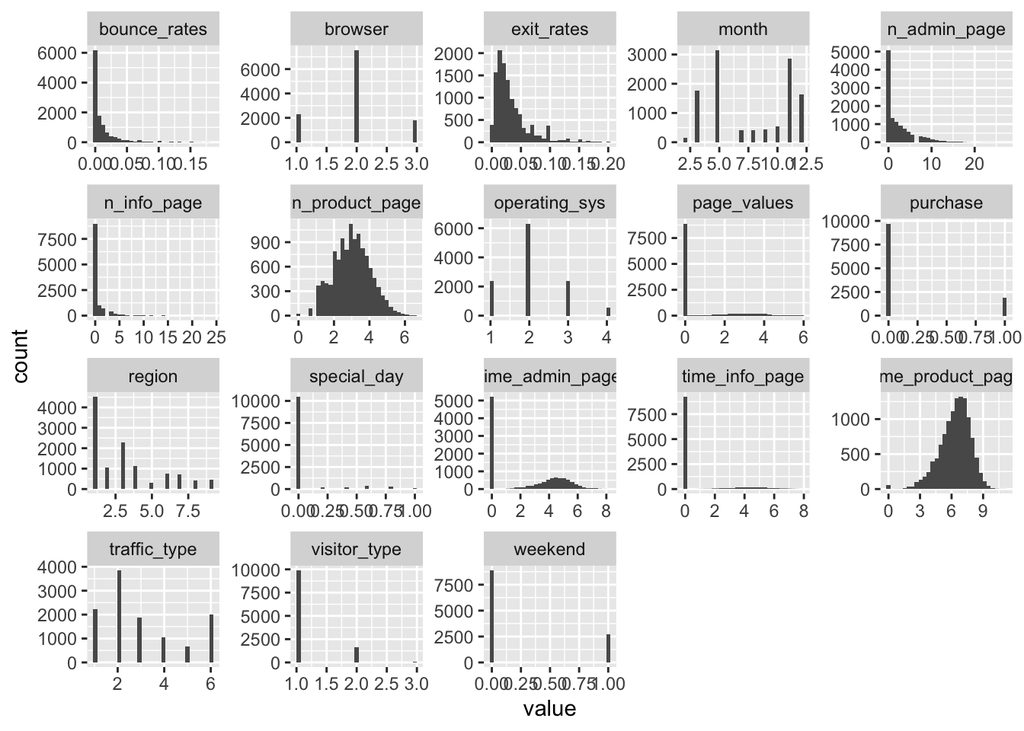

Figure 1: Histograms for the individual variables, where `n_product_page`, `page_values`, `time_admin_page`, `time_info_page`, and `time_product_page` are log-transformed.

This set of plot permit to highlight some habits of potential customers. Indeed, it seems like they spend much more time on product pages than on administration and information ones, where the majority of the customer didn’t even go. This may seem logical since they consult product pages much more than the others.

One can also observe that the number of “other visitor” is underrepresented in this data set, as well as a lake of observation during a special day or in certain months such as January or April, where we have no observation. However, the majority of the observations seems to be “new customer”.

Conversely, it seems that in most categorical variables, one factor is predominant. For example, most of the observations we have come from customers living in Region 1, or using browser 2.

# 2 Exploration Part

After this exhaustive description of the set, we can proceed to a larger exploration. In the preparatory phase, we have conducted an exploration of each variable and in this section, we report three interesting results that we consider relevant.

## 2.1 Value of pages consulted

The first feature we will discuss is the variable `page_values`. A very interesting one, since it is intuitive to assume that the higher the average page value of the visited pages, the more likely the client is to make a purchase. However it appears that most of the observations in our data set have a zero average. That is why on the previous graph, we observe a large spike at 0, that prevents us from clearly discerning the other values.

Thus, it may be interesting to concentrate on the observations that are non-zero average, which account for more than 23.47% of the data set. The Figures below illustrate this.

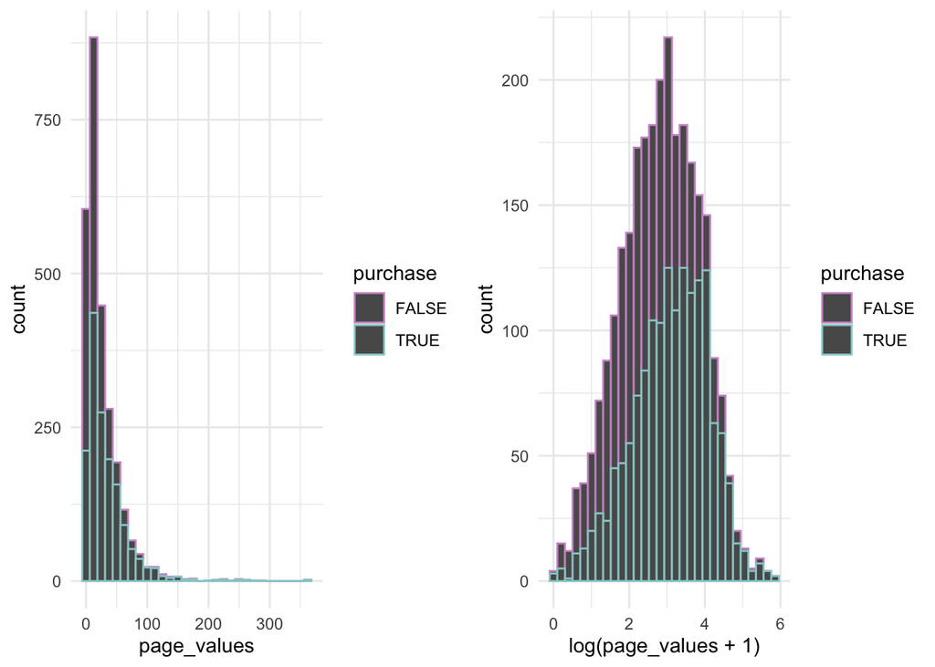

Figure 2: Histograms for the non-zero `page_values` variable with no transformation on the left and log-transformation on the rigth.

On these two histograms, the effects of the log transformation are clearly visible. Indeed, the log transformation reduces the skewness of our original data: large values are less far apart while small values are farther apart, making the graph much more readable.

Moreover, these histograms confirm our first intuition, as the proportion of “TRUE” purchases is generally high, especially for high averages. There is actually 80.73% of the client who purchased something that has consulting positive page values. This can be observed in the graph by the proportion of blue compared to purple. Another point to note is that although this proportion is high for all, it seems that the higher the average of the pages consulted, the greater the probability of making a purchase. The last peaks on the graph are almost entirely blue.

All these observations lead us to believe that in our regression analysis, the `page_values` variable will have an impact on or explain the `purchase` variable. However, at this point, it is impossible to evaluate the specific impact of a such variable.

## 2.2 Number of Product Page Visited

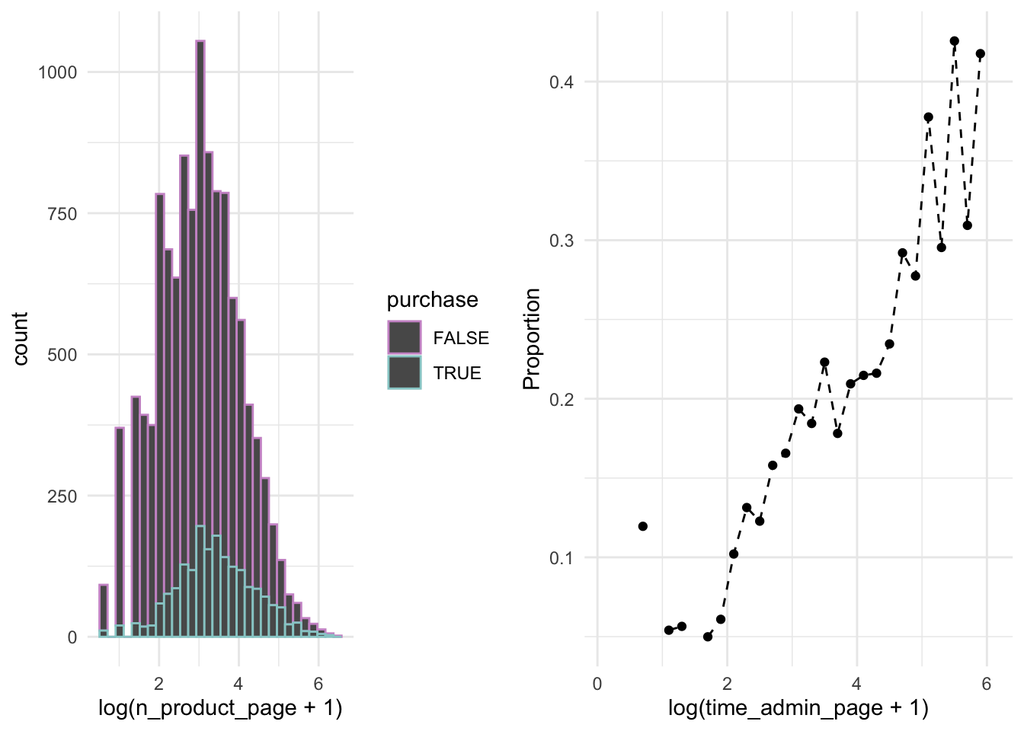

## 2.3 Christmas, Valentine’s Day, …

Moreover, one last thing that we notice is related to the variables `special_day` and `weekend`. In Figure 4, the last blue spike shows that every Special Day (such as Christmas or Valentine’s Day) where we registered an entry on the website happened to fall on a weekend. At this point in the analysis, we don’t know if it is a useful observation, but since we aim to understand how the odds of purchase are affected by date-related features, it is a result we can keep in mind.

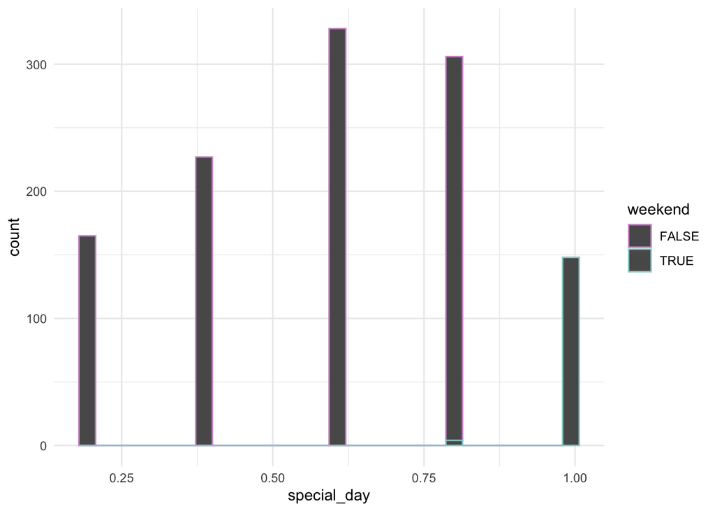

Figure 4: Histograms for the non-zero `special_day` variable.

# 3 Logistic Regression

## 3.1 Theory Part

As mentioned before, the variable of interest is a binary variable, and the most popular method to fit this kind of variable is the logistic regression. Indeed, it aims to determine the probability of a certain event occurring (in our case the “purchase event”) based on the characteristics of several independent variables.

Furthermore, the Bernoulli distribution belongs to the exponential family. Indeed, the density can be written :

$$f(y) = \pi^y (1 -
\pi)^{1-y}$$

$$f(y)=\exp(y \log(\frac{\pi}{1-\pi}) +
\log(1-\pi))$$

$$f(y) = \exp(y \theta + \log(1 +
e^\theta))$$
where $\theta = \log(\frac{\pi}{1 - \pi})$.

From here we can see that $\mu = \mathbb{E}[Y] = \pi = \frac{1}{1 + e^{-\theta}}$ and then obtain the canonical link function : $g(\mu)=\log(\frac{\mu}{1-\mu}) = \theta = X^T_n \beta$, which is called the logit function.

The $\beta_k$ are called the logit coefficients and reflect the size of the influence of the independent variables.

They will be estimated by maximizing the likelihood.

## 3.2 Model Selection

To fit a Generalized Linear Model (GLM) there is a very useful function in R, the `glm` from the package “stats”. We therefore begin by the full model (with every variables), more specifically it corresponds to the following formula :

Therefore it appears that some variables do not add much to the model, i.e have a high p-value. These variables are: `browser` and `region`. We then immediately fit another model without them. This action is encouraged by the 0.68 p-value obtained by the Likelihood Ration Test as shows the anova table below.

Table 1: Anova table to compare the full model and the one without the variables `browser` and `region`

| Resid. Df | Resid. Dev | Df | Deviance | Pr(>Chi) |
| --- | --- | --- | --- | --- |
| 11589 | 6075.7 |  |  |  |
| 11599 | 6083.22 | -10 | -7.51 | 0.68 |

On the other hand, it also emphasizes certain significant variables. One can find, in particular, the `page_values` (without surprise). It could then make sense to add interactions between the average of page values and the number of product, informative, and administrative pages consulted. This would indeed lead to new variables that would represent, respectively, the value of the product, informative, and administrative pages consulted. And as we aim to explain the odds of purchase affected by date-related features it can also be interesting to also add an interaction between `page_values` and `month`, `weekend`, `special_day`.

Moreover, after analyzing the residual plots, we could suggest allowing a quadratic dependence of the time spent on product pages, which indeed turns out to be significant.

By adding all these interactions and the quadratic term we can remark that the AIC value went from 6145.216 (when we already dropped the 2 first variables) to 5741.143.

Moreover, even if the Anova table suggests that every variable is significant we can test another model where we drop the less significant one, i.e `time_info_page`, `weekend`, and `operating_sys`. We also notice that the interaction between `page_values` and `weekend` seems to be the less significant one. And hence obtain a 0.424 p-value by the Likelihood Ration Test as shown in the following table :

Table 2: Anova table to compare the model with all the interactions and the one without the ones cited

[output not shown]

In conclusion, we obtain the model :

`purchase` ~ `page_values` * (`n_admin_page` + `n_info_page` + `n_product_page` + `month` + `special_day`) + `time_product_page` + `time_admin_page` + `bounce_rate` + `exit_rate` + `traffic_type` + `visitor_type` + `I(time_product_page^2)`

The summary of our final model is then :

```
##
## Call:
## glm(formula = purchase ~ . - browser - region - time_info_page -
##     weekend - operating_sys + I(time_product_page^2) + page_values *
##     (n_product_page + n_admin_page + n_info_page) + month * page_values +
##     page_values * special_day, family = "binomial", data = Data_final)
##
## Coefficients:
##                                 Estimate Std. Error z value Pr(>|z|)
## (Intercept)                    1.132e-01  4.863e-01   0.233 0.815978
## n_admin_page                   6.713e-02  1.768e-02   3.798 0.000146 ***
## time_admin_page               -4.960e-02  2.384e-02  -2.081 0.037457 *
## n_info_page                    6.558e-02  3.352e-02   1.956 0.050428 .
## n_product_page                 2.636e-01  9.234e-02   2.854 0.004314 **
## time_product_page             -1.054e+00  1.188e-01  -8.866  < 2e-16 ***
## bounce_rates                  -6.776e+00  4.586e+00  -1.478 0.139477
## exit_rates                    -1.219e+01  3.241e+00  -3.762 0.000169 ***
## page_values                    1.777e+00  1.488e-01  11.945  < 2e-16 ***
## special_day                   -6.397e-01  8.132e-01  -0.787 0.431484
## monthDec                      -5.644e-01  2.701e-01  -2.089 0.036671 *
## monthFeb                      -2.404e+00  1.508e+00  -1.594 0.110836
## monthJul                       3.748e-01  3.088e-01   1.214 0.224876
## monthJune                     -3.137e-01  4.086e-01  -0.768 0.442615
## monthMar                      -1.641e+00  3.257e-01  -5.039 4.67e-07 ***
## monthMay                      -2.206e+00  3.478e-01  -6.344 2.25e-10 ***
## monthNov                       7.457e-01  2.391e-01   3.119 0.001816 **
## monthOct                      -3.546e-01  3.200e-01  -1.108 0.267812
## monthSep                       2.466e-01  2.990e-01   0.825 0.409562
## traffic_type2                  1.973e-01  1.045e-01   1.889 0.058939 .
## traffic_type3                 -3.568e-02  1.368e-01  -0.261 0.794199
## traffic_type4                  1.067e-01  1.614e-01   0.661 0.508446
## traffic_type5                 -3.795e-01  2.085e-01  -1.820 0.068729 .
## traffic_type6                  3.731e-01  1.213e-01   3.077 0.002094 **
## visitor_typeOther             -4.354e-01  5.033e-01  -0.865 0.386944
## visitor_typeReturning_Visitor -4.485e-01  1.084e-01  -4.138 3.51e-05 ***
## I(time_product_page^2)         8.401e-02  1.007e-02   8.340  < 2e-16 ***
## n_product_page:page_values    -1.685e-01  3.067e-02  -5.492 3.97e-08 ***
## n_admin_page:page_values      -5.010e-02  6.877e-03  -7.286 3.20e-13 ***
## n_info_page:page_values       -3.512e-02  1.576e-02  -2.228 0.025853 *
## page_values:monthDec          -4.527e-03  1.271e-01  -0.036 0.971574
## page_values:monthFeb           4.689e-01  5.410e-01   0.867 0.386130
## page_values:monthJul          -2.147e-01  1.584e-01  -1.355 0.175385
## page_values:monthJune          8.628e-05  2.042e-01   0.000 0.999663
## page_values:monthMar           6.870e-01  1.492e-01   4.605 4.12e-06 ***
## page_values:monthMay           6.536e-01  1.460e-01   4.478 7.54e-06 ***
## page_values:monthNov          -9.272e-02  1.192e-01  -0.778 0.436830
## page_values:monthOct           1.205e-01  1.504e-01   0.801 0.422884
## page_values:monthSep          -2.263e-01  1.475e-01  -1.534 0.124953
## page_values:special_day        5.237e-01  3.279e-01   1.597 0.110245
## ---
## Signif. codes:  0 '***' 0.001 '**' 0.01 '*' 0.05 '.' 0.1 ' ' 1
##
## (Dispersion parameter for binomial family taken to be 1)
##
##     Null deviance: 10372.1  on 11629  degrees of freedom
## Residual deviance:  5655.1  on 11590  degrees of freedom
## AIC: 5735.1
##
## Number of Fisher Scoring iterations: 8
```

In the summary, some variables like `special_day`, which was significant in the anova table, don’t appear this way in the summary. But as we mention in the exploration part, this may be due to the lack of data and so we decide to keep it in the model. Another one is `bounce_rate`, however removing it from the model increases the AIC, so we choose to keep it as well.

## 3.3 Interpretation of the Coefficients

In theory, the equation associated to our model looks like :
$$z_n = X_n \beta = \beta_1 + X_{n,2} \beta_2 + ...
+ X_{n, p} \beta_p$$
where every $\beta$ is a coefficient associated to one variable (or one level in the case of a categorical variable) and then

$$P(Y=1 | X = X_n) = \frac{1}{1 +
\exp(-z_n)}$$

Hence, the idea is that a negative coefficient will decrease the probability of purchasing something as the corresponding feature increases. On the other hand, a positive coefficient will increase the probability.

However, the precise interpretation depends on the variable. We have to distinguish the intercept from the numerical variables and the categorical ones.

**The intercept**

We know that the intercept captures odd of success with zero regressors, so by replacing in the previous formula we obtain :
$$[\pi_0 = ] \space \space \space \space P(Y=1 | X
= (0, ..., 0)) = \frac{1}{1 + \exp(-\beta_1)}$$
So $\exp(\beta_1) = \frac{\pi_0}{1 - \pi_0}$.

**Numerical Variables**

For numerical variable, the coefficient captures odds ratio (between two observations that differ by 1 in the corresponding regressor). Let’s take for example the feature `n_admin_page` ($nap$):

$$z_n = X_n \beta = \beta_1 + X_{n,nap}
\beta_{nap} + ...$$

So if we take two different observations such that : $X_1 = (x_{1, nap}, ... , x_{1, time-prod})$ and $X_2 = (x_{1, nap} +1, ... , x_{1, time-prod})$. We obtain :

- $\pi_1 = P(Y=1 | X = X_1)$, which leads to $\beta^T X_1 = \log(\frac{\pi_1}{1 - \pi_1})$
- $\pi_2 = P(Y=1 | X = X_2)$, which leads to $\beta^T X_2 = \log(\frac{\pi_2}{1 - \pi_2})$

And by subtracting we obtained : $\exp(\beta_{nap}) = \frac{\pi_1 (1 - \pi_2)}{\pi_2 (1 - \pi_1)}$ or $\log(\frac{\pi_2}{1 - \pi_2}) = \log(\frac{\pi_1}{1 - \pi_1}) + \beta_{nap}$ which leads to $\frac{\pi_2}{1 - \pi_2} = \frac{\pi_1}{1 - \pi_1} \exp(\beta_{nap})$. So as the coefficient of this feature is 0.07, we can conclude that the addition of one administration page is associated with a 7% increase in the odds of purchasing something (as $\exp(0.07) = 1.07$) holding all other predictors constant.

But for some variables like `page_values` we did a log transformation, and we have to take it into account in our interpretation :

$$z_n = X_n \beta = \beta_1 + X_{n,nap}
\beta_{nap} + \log(X_{n,pv} +1) \beta_{pv} + ...$$
And so a one unit increase in $\log(X_{n,pv} +1)$ corresponds to a multiplication of the odds by 6.05 (as the coefficient of the page values is 1.8 and $\exp(1.8) = 6.05$).

**Categorical Variables**

For categorical variables, let’s take for example the feature `traffic_type` (tt):

$$z_n = X_n \beta = \beta_1 +
I_{(X_{n,tt}==2)} \beta_{tt2} + ... + I_{(X_{n,tt}==6)}
\beta_{tt6} +...$$
In this example, the reference categorical is the “traffic type 1”. And each coefficient associated to a categorical variable represents the difference in log - odds of purchasing something compare to the odds’s reference. We indeed have for instance : $X_1 = (tt1, x_{pv}... )$ and $X_2 = (tt2, x_{pv}... )$. We obtain :

- $\pi_1 = P(Y=1 | X = X_1)$ leads to $\beta^T X_1 = \log(\frac{\pi_1}{1 - \pi_1})$
- $\pi_2 = P(Y=1 | X = X_2)$ leads to $\beta^T X_2 = \log(\frac{\pi_2}{1 - \pi_2})$

And then by subtracting :
$$\beta_{tt2} =
\log(\frac{\pi_2}{1 - \pi_2}) - \log(\frac{\pi_1}{1 -
\pi_1})$$
.

Then, using the same calculation as in the previous case, we determined that having traffic type 2 instead of type 1 increases the odds of purchasing something by 21% (as exp(0.197) = 1.21).

# 4 Model Checking

## 4.1 Residuals Diagnostic

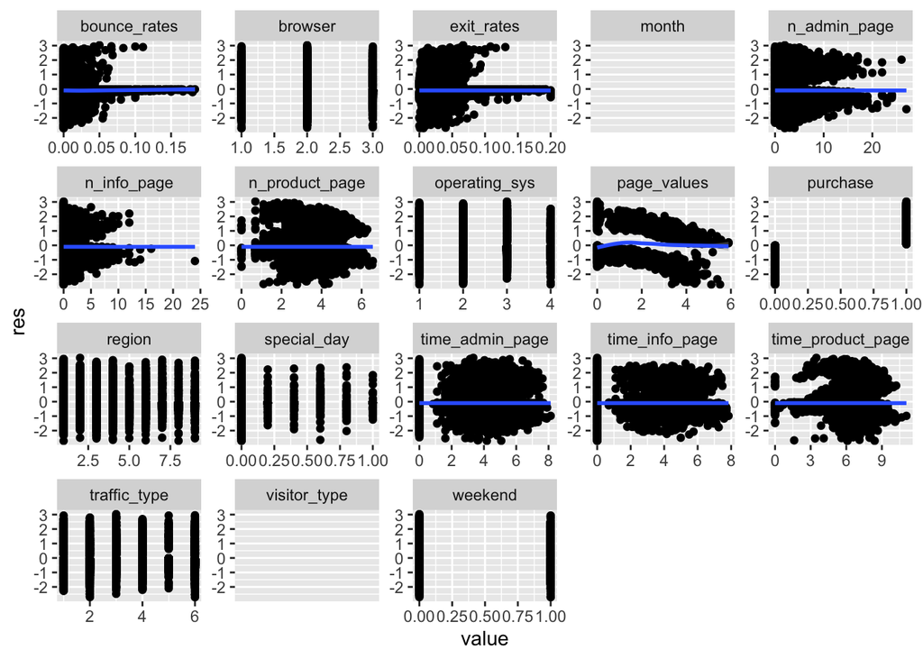

Moreover by inspecting the cook distance of the observations, which is a measure that estimate the influence of a data point when performing a regression, we confirm that none has a very high value which is also a good news.

## 4.2 Model Evaluation

**AUC Curve**

An important concept in evaluating binary classification is the ROC Curve. It is a curve that plots the true positive rate against the false positive rate. A more suitable model will approach the upper-right corner of the curve, where the true positive rate is close to 1 and the false positive rate is close to 0. An effective and common method is then to calculate the area under this ROC Curve. The model with the largest area is chosen. Additionally, it can be added that the area under the curve typically ranges from 0.5 to 1. If a curve falls below 0.5, one can simply invert the predicted values of the algorithm. For example, if a curve passes through the lower-right corner, it indicates a very good model that predicts the opposite value. In this case, an area of 0.5 under the curve represents the worst model with completely random classification.

To calculate it we use the function provided in the slides of the course, and we obtain for our final model: 0.92, which is higher than the Benchmark AUC (0.895).

**Residual Deviance**

When fitting a generalized linear model, such as in this case for a classification model, it is common to use residual deviance as an evaluation measure. Residual deviance is calculated as the difference between the log-likelihood of the fitted model and the log-likelihood of the saturated model. Therefore, a lower residual deviance indicates a better model.

We now summarize all the results of our model in the following table.

Table 3: AIC, Residual Deviance and AUC value of our final model.

| AIC | Residual Deviance | AUC value |
| --- | --- | --- |
| 5735.136 | 5655.136 | 0.9234712 |

# 5 Discussion

In conclusion, in this report, we fitted a model to understand the behavior of customer in the website. And according to the previous part it seems to be a good one as the AUC is close to 1, and there is an acceptable residual deviance.

By analyzing the summary and the explication given in the following part, we can now understand the behavior of customers. For example, we notice that the coefficient of the variable `time_admin_page` is negative, which implies that the more time a person spends on these pages, the less likely they are to buy. However, the positive coefficient in front of `n_admin_page` implies that when a person consults these pages, he is already more likely to buy. This could be translated by the fact that when a person has decided to buy and goes to the administrative pages, the purchase will be abandoned if they are too complex or long. So, it might be useful for the company to check the efficiency and clarity of these pages.

Of course, we also noticed some results that we remarked in the exploration part, like the more the average value of pages visited is high the more the probability of purchasing something is high. Nevertheless, this result should be emphasized twice. This variable plays a determining role in our model; it is indeed very significant and is present in many interactions. This means that the company must support and research as much as possible on this criterion to hope to improve its sales.

But some surprising results occur, such as the three coefficients of the model’s interactions with the pages are negative. However, since they represent the sum of the values of the observed pages in each category (and on average), one would expect the coefficients to be positive. But we can assume that this interaction is intended to attenuate the large effect of the page values variable.

# 6 Other possible model

We have to admit that we have in fact explored very few interactions among all the possible ones. With more time, it would surely have been possible to find a more accurate model (even if all models are wrong).

Upon further consideration, it would be beneficial to include additional variables in the data set. Specifically, we should consider adding an indicator that reflects whether the customer viewed pages with value or not. Since most of them did not do so, despite this parameter being very important in the purchase. So, due to the limited number of observations, the coefficient’s results may be biased. By introducing this indicator, we can mitigate the impact of this phenomenon.

By the same reasoning, we can also put an indicator to inform if the customer has consulted pages with some values or not.

| AIC | Residual Deviance | AUC value |
| --- | --- | --- |
| 5496.525 | 5392.525 | 0.9282552 |